# Sampling Distributions

Himansu Sahoo

November 03, 2015

Below are a quick summary of commands for statistics in R.

### Get the dataset and make samples

```r
# Load the 'ames' data frame:
load(url("http://assets.datacamp.com/course/dasi/ames.RData"))

# Make some preliminary inspections:
dim(ames)
```

```
## [1] 2930   82
```

```r
#names(ames)
#head(ames)
#tail(ames)

area <- ames$Gr.Liv.Area
price <- ames$SalePrice

# Calculate the summary and draw a histogram of 'area'
summary(area)
```

```
##    Min. 1st Qu.  Median    Mean 3rd Qu.    Max.
##     334    1126    1442    1500    1743    5642
```

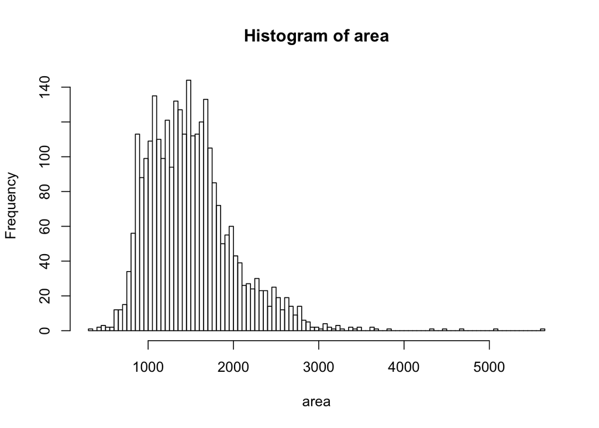

```r
hist(area, breaks=80)
```

```r
length(area)
```

```
## [1] 2930
```

```r
#head(area)
area[1:20]
```

```
##  [1] 1656  896 1329 2110 1629 1604 1338 1280 1616 1804 1655 1187 1465 1341
## [15] 1502 3279 1752 1856  864 2073
```

### Sampling from population

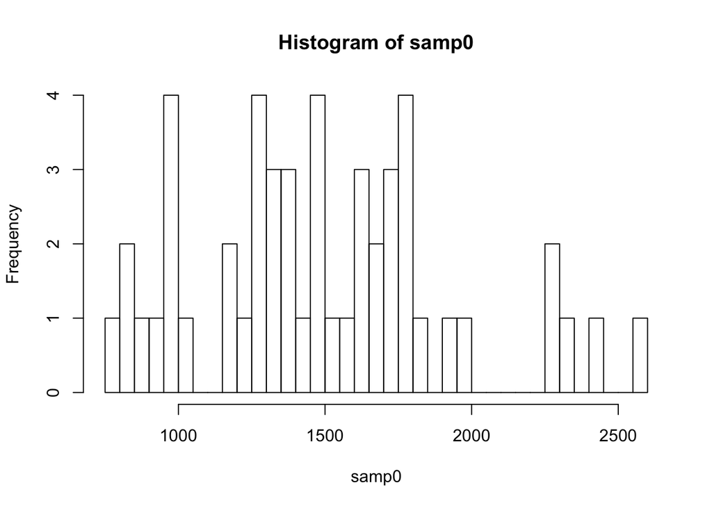

```r
# take a sample of size 50 from area
samp0 <- sample(area, 50)
hist(samp0, breaks=50)
```

```r
length(samp0)
```

```
## [1] 50
```

```r
#head(samp0)
samp0[1:20]
```

```
##  [1] 1702 1453 1295 1592 1512 2322 1491 1622  860 1248 1930 1340 1020 1772
## [15] 1776 1760 2262 1328 1336 1690
```

Not surprisingly, every time we take another random sample, we get a different sample mean. It’s useful to get a sense of just how much variability we should expect when estimating the population mean this way. *The distribution of sample means, called the sampling distribution*, can help us understand this variability. In this lab, because we have access to the population, we can build up the sampling distribution for the sample mean by repeating the above steps many times. Here we will generate 5000 samples and compute the sample mean of each.

### sampling distribution

```r
# Set up an empty vector of 5000 NAs to store sample means:
sample_means10 <- rep(NA, 5000)
sample_means50 <- rep(NA, 5000)
sample_means100 <- rep(NA, 5000)

# Take 5000 samples of size 50 of 'area' and store all of them in 'sample_means50'.
for (i in 1:5000) {
     samp10 <- sample(area, 10)
   samp50 <- sample(area, 50)
   samp100 <- sample(area, 100)

   sample_means10[i] <- mean(samp10)
   sample_means50[i] <- mean(samp50)
   sample_means100[i] <- mean(samp100)
}

# View the result. If you want, you can increase the bin width to show more detail by changing the 'breaks' argument.
#hist(sample_means50, breaks = 100)

# Print the first few random means
#head(sample_means50)

sample_means10[1:10]
```

```
##  [1] 1525.9 1421.9 1505.9 1580.3 1436.8 1227.2 1285.7 1292.8 1447.8 1372.2
```

```r
sample_means50[1:10]
```

```
##  [1] 1597.32 1427.48 1649.06 1643.84 1454.14 1526.52 1572.36 1490.52
##  [9] 1440.38 1429.20
```

```r
sample_means100[1:10]
```

```
##  [1] 1489.18 1449.99 1457.11 1459.61 1492.21 1436.27 1433.24 1511.58
##  [9] 1430.34 1485.05
```

```r
#summary(sample_means10)
#summary(sample_means50)
#summary(sample_means100)
mean(sample_means10); sd(sample_means10)
```

```
## [1] 1496.799
```

```
## [1] 159.9615
```

```r
mean(sample_means50); sd(sample_means50)
```

```
## [1] 1500.154
```

```
## [1] 71.60411
```

```r
mean(sample_means100); sd(sample_means100)
```

```
## [1] 1500.899
```

```
## [1] 50.42884
```

#### Plot three histograms

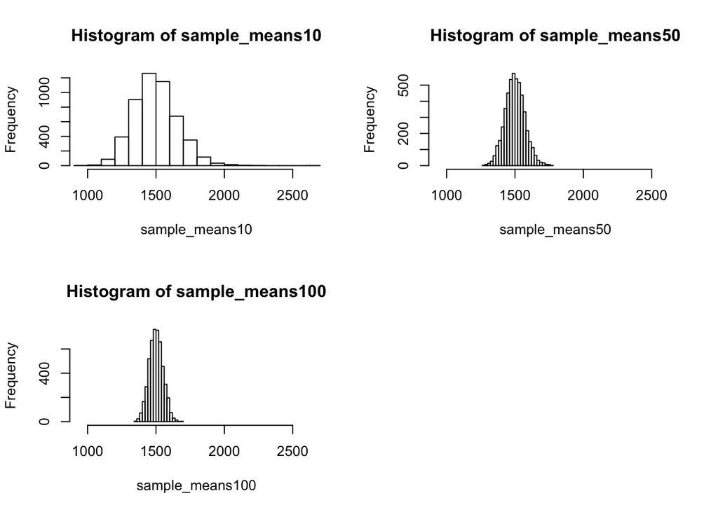

```r
# Divide the plot in 3 rows:
par(mfrow = c(2, 2))

# Define the limits for the x-axis:
xlimits <- range(sample_means10)

# Draw the histograms:
hist(sample_means10, breaks=20, xlim=xlimits)
hist(sample_means50, breaks=20, xlim=xlimits)
hist(sample_means100, breaks=20, xlim=xlimits)
```

### 95% Confidence Intervals

based on this sample, what can we infer about the population? Based only on this single sample, the best estimate of the average living area of houses sold in Ames would be the *sample mean*. That serves as a good point estimate but it would be useful to also communicate how uncertain we are of that estimate. This can be captured by using a confidence interval. We can calculate a *95% confidence interval* for a sample mean by adding and subtracting *1.96 standard errors* to the point estimate. It is an important inference that we make with this: even though we don’t know what the full population looks like, we’re 95% confident that the true average size of houses in Ames lies between the values lower and upper.

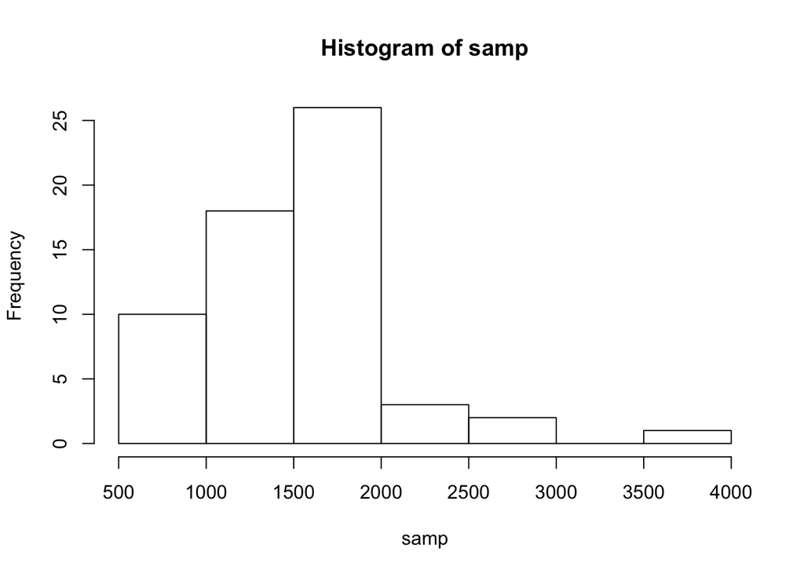

```r
# Take a sample of size 60 of the population:
population <- ames$Gr.Liv.Area
samp <- sample(population, 60)

# Calculate the mean:
sample_mean <- mean(samp)

# Draw a histogram:

hist(samp)
```

```r
# Calculate the standard error:
se <- sd(samp)/sqrt(60)

# Calculate the lower and upper bounds of your confidence interval and print them:
lower <- sample_mean - 1.96 * se
upper <- sample_mean + 1.96 * se

c(lower, upper)
```

```
## [1] 1409.546 1681.887
```

How sample means and confidence intervals vary from one sample to another.

Using R, we’re going to recreate many samples using a for loop. Here is the rough outline: Obtain a random sample. Calculate the sample’s mean and standard deviation. Use these statistics to calculate a confidence interval.

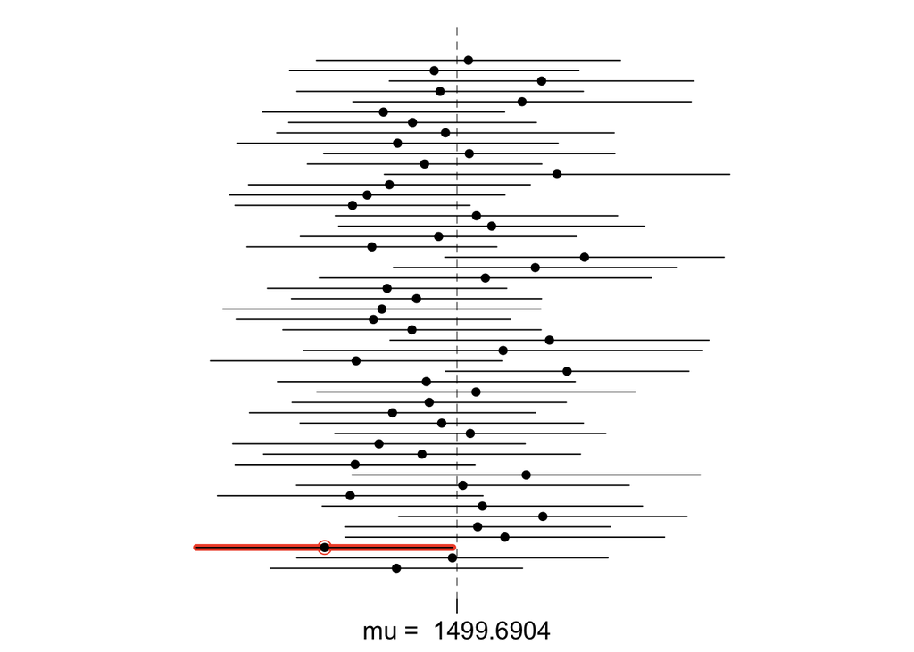

```r
# Initialize 'samp_mean', 'samp_sd' and 'n':
samp_mean <- rep(NA, 50)
samp_sd <- rep(NA, 50)
n <- 60

# For loop goes here:
for (i in 1:50) {
  samp <- sample(population, n)
  samp_mean[i] <- mean(samp)
  samp_sd[i] <- sd(samp)
}

# Calculate the interval bounds here:
lower <- samp_mean - 1.96 * (samp_sd/sqrt(n))
upper <- samp_mean + 1.96 * (samp_sd/sqrt(n))

# Plotting the confidence intervals:
pop_mean <- mean(population)
plot_ci(lower, upper, pop_mean)
```

### 99% Confidence Level

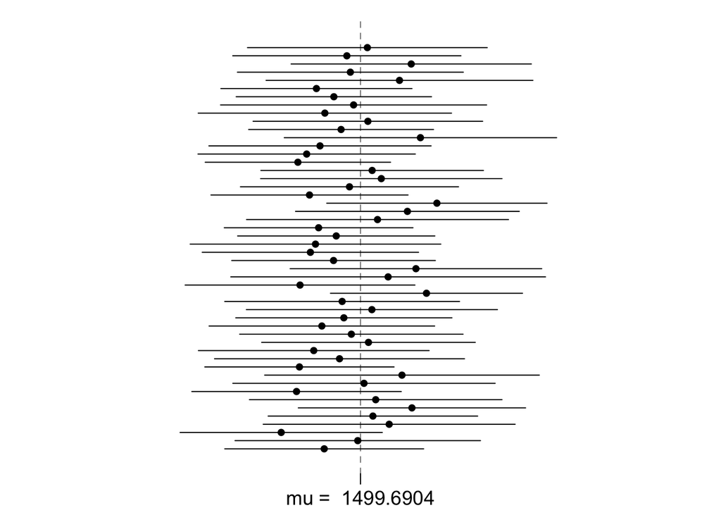

```r
# Calculate the interval bounds here:
lower_99 <-  samp_mean - 2.58 * (samp_sd/sqrt(n))
upper_99 <- samp_mean + 2.58 * (samp_sd/sqrt(n))

# Plotting the confidence intervals:
pop_mean <- mean(population)
plot_ci(lower_99, upper_99, pop_mean)
```